# R Notebook

```r
file.choose()
```

```
[1] "/Users/Lee/Documents/Git Repository/QuanEco/time series/ARIMA_Workshop.RData"
```

```r
load("~/Documents/Git Repository/QuanEco/time series/ARIMA_Workshop.RData")
```

creating a time series objects, mangroves NEE daily data with 30 observations per month.

```r
nee <- ts( mangroves$nee, start= 1, frequency=30)
```

visualizing the mangroves NEE daily data with 30 observations per month for 12 months.

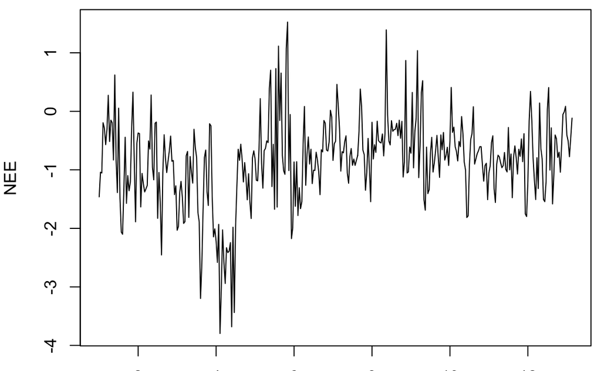

```r
par(mfrow=c(1,1), mai=c(0.25,0.8,0.1, 0.1))
plot( nee, typ="l", ylab= "NEE", xlab="months")
```

"You want to remove any outliers that could bias the model by skewing statistical summaries. R provides a convenient method for removing time series outliers: tsclean() as part of its forecast package. tsclean() identifies and replaces outliers using series smoothing and decomposition.

tsclean will smooth the data set and remove outliers (just to visualize)

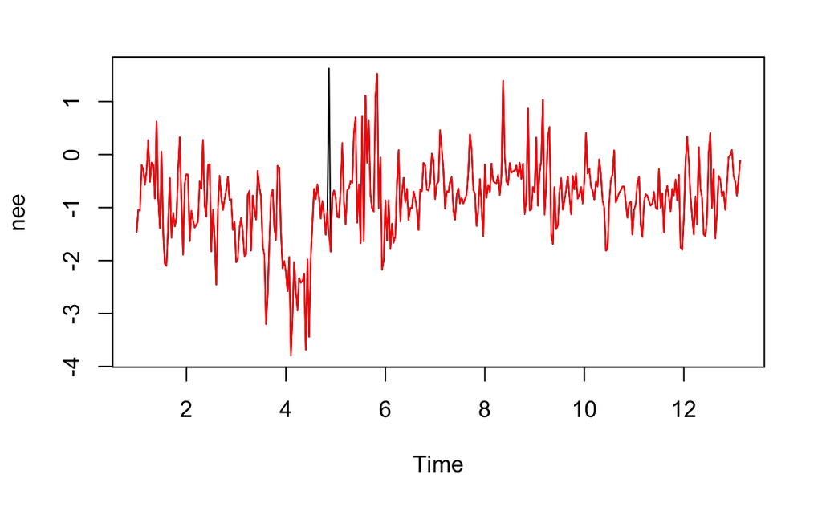

```r
plot(nee)
lines(tsclean(nee), col="red")
```

This code actually cleans the data

```r
nee <- tsclean(nee)
```

This code will decompose the data so that we may separate seasonality, trends, and error associated with timeseries data. we are decomposing the time series

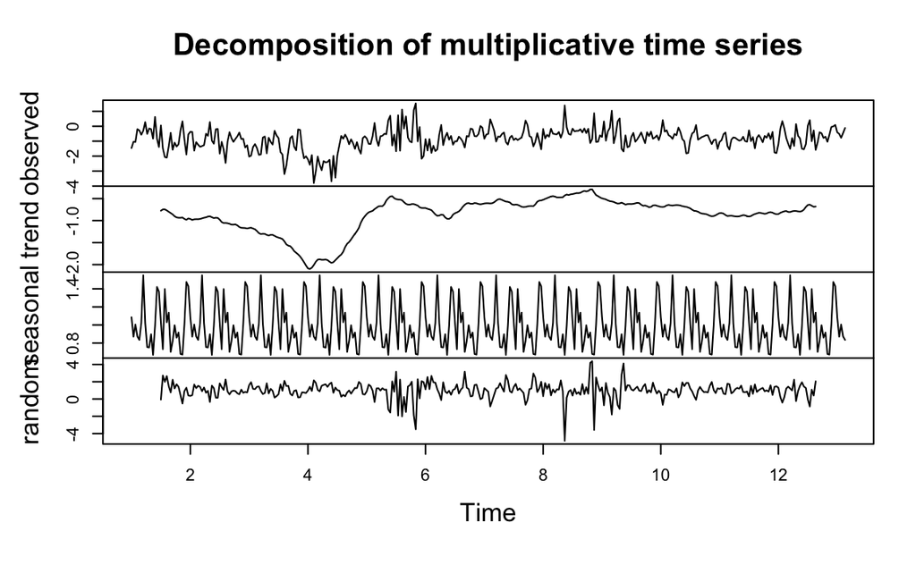

```r
nee.d <- decompose(nee, 'multiplicative')
plot(nee.d)
```

because we are applying the ARIMA model, the model must be stationary. “(A series is stationary when its mean, variance, and autocovariance are time invariant.)” p-value < 0.05 indicates the TS is stationary

```r
adf.test(nee )
```

```
p-value smaller than printed p-value
```

```
    Augmented Dickey-Fuller Test

data:  nee
Dickey-Fuller = -4.4703, Lag order = 7, p-value = 0.01
alternative hypothesis: stationary
```

Now we ae detecting autocorrelations. Also useful for visual tool to find whether series is stationary. displays correlation between a series and its lags.

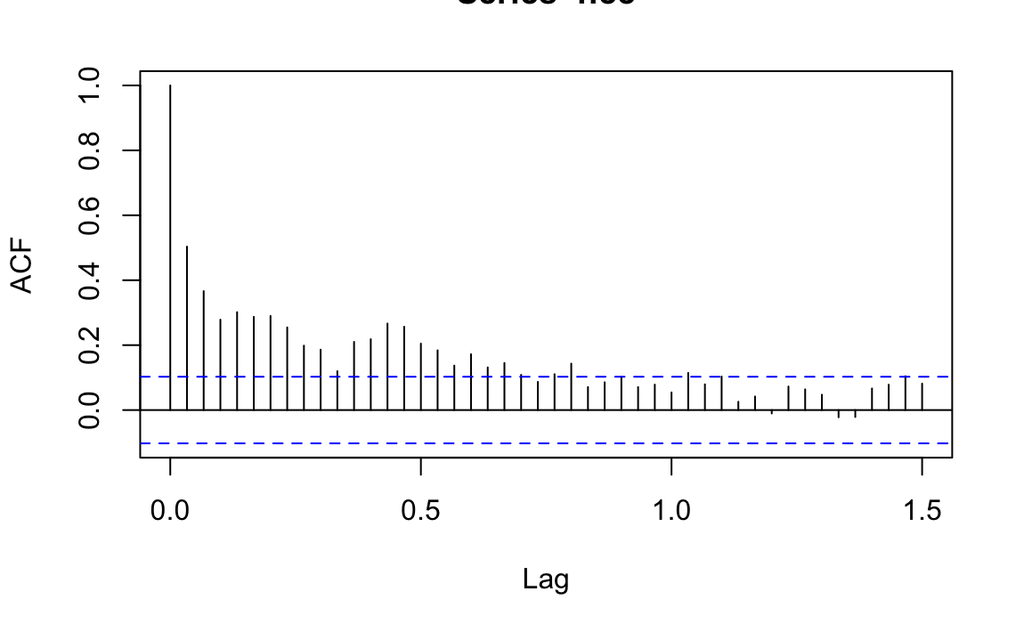

```r
acf(nee, lag.max=45)
```

here we just do a partial autocorrelation, refer to pdf for full understanding

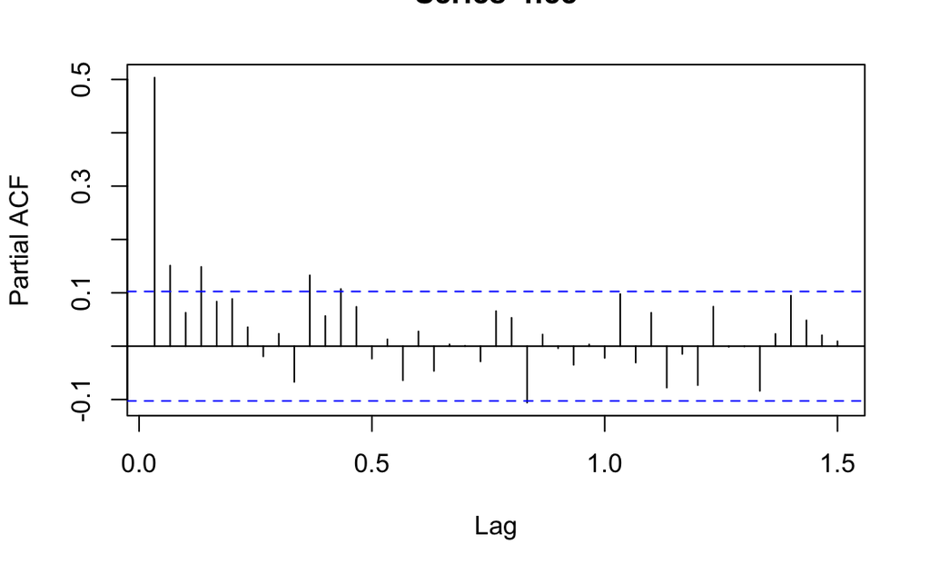

```r
pacf(nee, lag.max=45)
```

Here we are going to fit an ARIMA model to our data

```r
arima.nee1 <-auto.arima(nee, trace=TRUE)
```

```
 Fitting models using approximations to speed things up...

 ARIMA(2,1,2)(1,0,1)[30] with drift         : 692.3276
 ARIMA(0,1,0)            with drift         : 812.1839
 ARIMA(1,1,0)(1,0,0)[30] with drift         : 754.1
 ARIMA(0,1,1)(0,0,1)[30] with drift         : 716.6018
 ARIMA(0,1,0)                               : 810.171
 ARIMA(2,1,2)(0,0,1)[30] with drift         : 700.2522
 ARIMA(2,1,2)(1,0,0)[30] with drift         : 690.6777
 ARIMA(2,1,2)            with drift         : 699.6979
 ARIMA(2,1,2)(2,0,0)[30] with drift         : 693.2668
 ARIMA(2,1,2)(2,0,1)[30] with drift         : 683.2512
 ARIMA(2,1,2)(2,0,2)[30] with drift         : 684.2198
 ARIMA(2,1,2)(1,0,2)[30] with drift         : 693.9678
 ARIMA(1,1,2)(2,0,1)[30] with drift         : 687.2495
 ARIMA(2,1,1)(2,0,1)[30] with drift         : 688.6439
 ARIMA(3,1,2)(2,0,1)[30] with drift         : 684.767
 ARIMA(2,1,3)(2,0,1)[30] with drift         : 680.7186
 ARIMA(2,1,3)(1,0,1)[30] with drift         : 691.8705
 ARIMA(2,1,3)(2,0,0)[30] with drift         : 693.7771
 ARIMA(2,1,3)(2,0,2)[30] with drift         : 680.1553
 ARIMA(2,1,3)(1,0,2)[30] with drift         : Inf
 ARIMA(1,1,3)(2,0,2)[30] with drift         : 685.9808
 ARIMA(3,1,3)(2,0,2)[30] with drift         : 687.4705
 ARIMA(2,1,4)(2,0,2)[30] with drift         : 682.0784
 ARIMA(1,1,2)(2,0,2)[30] with drift         : 688.6414
 ARIMA(1,1,4)(2,0,2)[30] with drift         : 687.389
 ARIMA(3,1,2)(2,0,2)[30] with drift         : Inf
 ARIMA(3,1,4)(2,0,2)[30] with drift         : Inf
 ARIMA(2,1,3)(2,0,2)[30]                    : 679.2322
 ARIMA(2,1,3)(1,0,2)[30]                    : 691.5612
 ARIMA(2,1,3)(2,0,1)[30]                    : 679.7025
 ARIMA(2,1,3)(1,0,1)[30]                    : 689.9659
 ARIMA(1,1,3)(2,0,2)[30]                    : Inf
 ARIMA(2,1,2)(2,0,2)[30]                    : 682.9001
 ARIMA(3,1,3)(2,0,2)[30]                    : 686.0237
 ARIMA(2,1,4)(2,0,2)[30]                    : 681.2665
 ARIMA(1,1,2)(2,0,2)[30]                    : 688.0739
 ARIMA(1,1,4)(2,0,2)[30]                    : 686.5791
 ARIMA(3,1,2)(2,0,2)[30]                    : 684.2254
 ARIMA(3,1,4)(2,0,2)[30]                    : 688.1532

 Now re-fitting the best model(s) without approximations...

 ARIMA(2,1,3)(2,0,2)[30]                    : 706.7137

 Best model: ARIMA(2,1,3)(2,0,2)[30]
```

Here we examine ACF and PACF lpots for model residuals. We would expect no significant autocorrelations if model order parameters and structure are correclty specified.

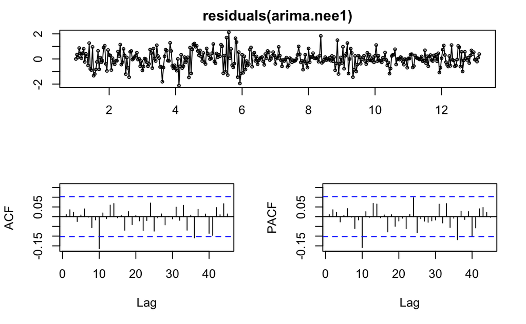

Now displaying the residuals from 2nd ARIMA

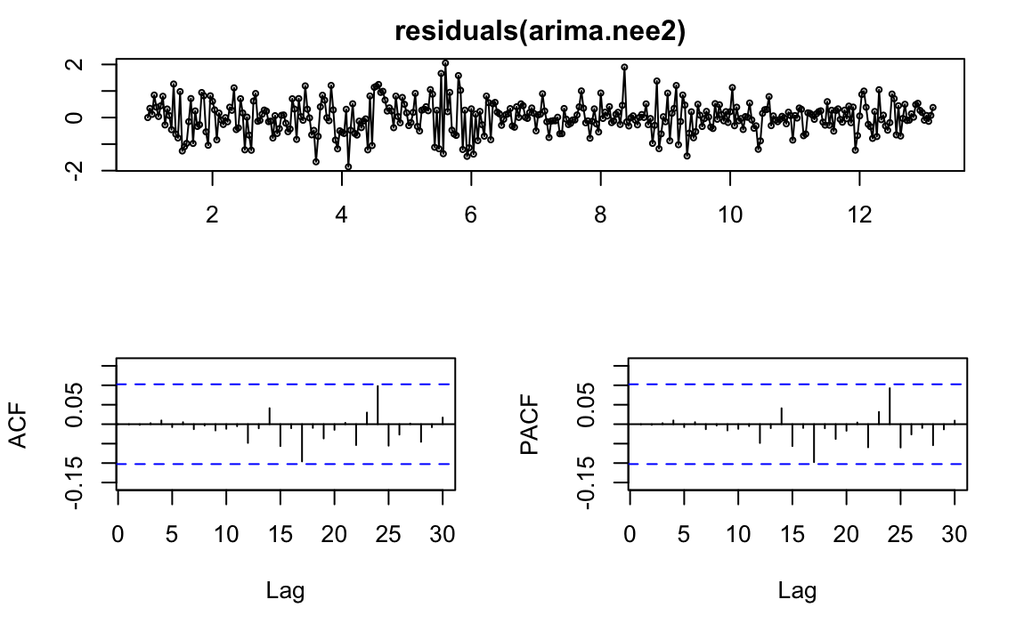

```r
tsdisplay(residuals(arima.nee2), lag.max= 30)
```

You want to minimize AIC

```r
AIC(arima.nee1, arima.nee2)
```

|  | df | AIC |
| --- | --- | --- |
| arima.nee1 | 10 | 706.0904 |
| arima.nee2 | 18 | 704.7663 |

To compare models we use AIC, we also want to compare observed versus predicted values. nee2 does better (has a lower value during our test, accounts for more variation)

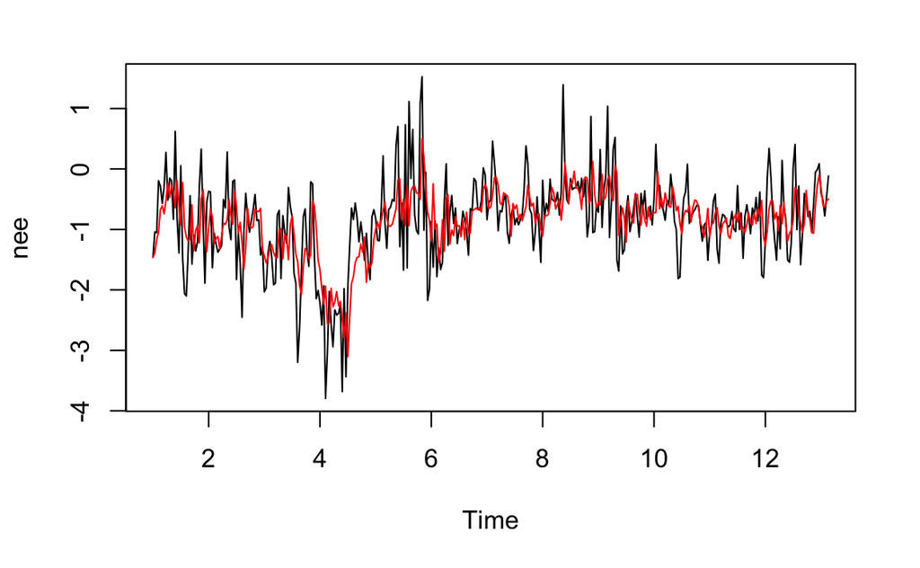

```r
 par(mfrow=c(1,1))
plot(nee , typ="l"); lines(fitted(arima.nee2),col="red")
```

Measuring for significant difference from white noise. You need a p-value greater than 0.05!

```
    Ljung-Box test

data:  Residuals from ARIMA(10,1,3)(2,0,2)[30]
Q* = 23.111, df = 19, p-value = 0.2325

Model df: 17.   Total lags used: 36
```

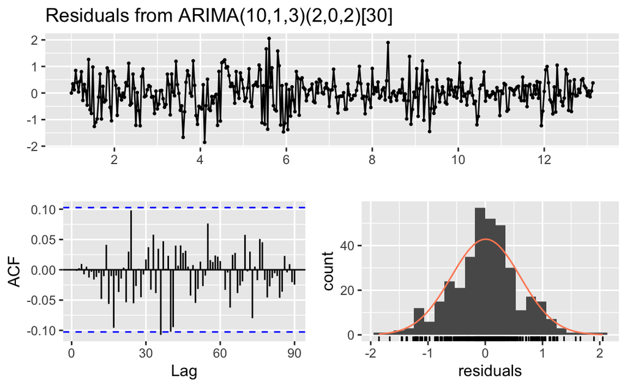

```r
checkresiduals(arima.nee2, lag=36)
```

[figure not shown]

Forecasts from ARIMA ((10,1,3)(2,0,2)[30]) which will predict future NEE

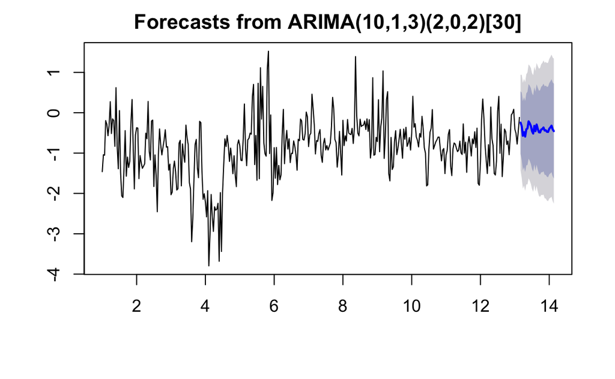

```r
plot(forecast(arima.nee2, h=30))
```

NOW ONTO THE ACTUAL EXCERCISE

# naming and grabbing mangrove salinity data for year, daily measurments, 30 a month

sal <- ts(mangroves$salinity.max, start= 1, frequency=30)

# visualizing the data pulled from last line

par(mfrow=c(1,1), mai=c(0.25,0.8,0.1, 0.1)) plot(sal , typ=“l”, ylab= “Salinity”, xlab="")

# visualize outliers

sal.d <- decompose(sal, ‘multiplicative’) plot(sal.d)

# p-value < 0.05 indicates the TS is stationary

adf.test(sal)

adf.test(diff(sal))

ccf( diff(sal),nee, na.action = na.pass, lag.max=40, plot=TRUE)

arima.nee3 <-auto.arima(nee, xreg=c(diff(sal),0), trace=TRUE)

#compare to current model AIC(arima.nee2, arima.nee3 )

arima.nee4 <-auto.arima(nee, xreg=sal.i, trace=TRUE)

AIC(arima.nee2,arima.nee4 )

checkresiduals(arima.nee4, lag=36)

par(mfrow=c(1,1)) plot(nee , typ=“l”); lines(fitted(arima.nee4),col=“red”)